# Covid regression

8/12/2020

## Regression problem

- We will run regression and other related models for Covid-19 data

## Libiraries

- We will use the following packages

```r
library(tidyverse)
library(caret)
library(glmnet)
```

## Load data

The data we will use is the following data. It is a combined dataset from three data sourse we have been using. The code for processing is available at `data_prep/data_preparation.R`.

```r
data_covid <- read_csv("data/covid-data.csv.gz")
```

## Check data

Let’s have a cursory look at the data, especially check the distribution of the output variable `deaths_per1000` Do we need conversion?

### `head()`

```r
head(data_covid)
```

```
## # A tibble: 6 x 48
##    fips county state   lat  long date       cases state_code deaths pct_report
##   <dbl> <chr>  <chr> <dbl> <dbl> <date>     <dbl> <chr>       <dbl>      <dbl>
## 1  1001 Autau~ Alab~  32.5 -86.6 2020-08-08  1086 AL             21          1
## 2  1003 Baldw~ Alab~  30.7 -87.7 2020-08-08  3502 AL             24          1
## 3  1005 Barbo~ Alab~  31.9 -85.4 2020-08-08   573 AL              5          1
## 4  1007 Bibb   Alab~  33.0 -87.1 2020-08-08   426 AL              5          1
## 5  1009 Blount Alab~  34.0 -86.6 2020-08-08   788 AL              4          1
## 6  1011 Bullo~ Alab~  32.1 -85.7 2020-08-08   463 AL             11          1
## # ... with 38 more variables: votes <dbl>, total_votes <dbl>, pct <dbl>,
## #   lead <chr>, TotalPop <dbl>, Men <dbl>, Women <dbl>, Hispanic <dbl>,
## #   White <dbl>, Black <dbl>, Native <dbl>, Asian <dbl>, Pacific <dbl>,
## #   VotingAgeCitizen <dbl>, Income <dbl>, IncomePerCap <dbl>, Poverty <dbl>,
## #   ChildPoverty <dbl>, Professional <dbl>, Service <dbl>, Office <dbl>,
## #   Construction <dbl>, Production <dbl>, Drive <dbl>, Carpool <dbl>,
## #   Transit <dbl>, Walk <dbl>, OtherTransp <dbl>, WorkAtHome <dbl>,
## #   MeanCommute <dbl>, Employed <dbl>, PrivateWork <dbl>, PublicWork <dbl>,
## #   SelfEmployed <dbl>, FamilyWork <dbl>, Unemployment <dbl>,
## #   cases_per1000 <dbl>, deaths_per1000 <dbl>
```

### Check the distribution of the output

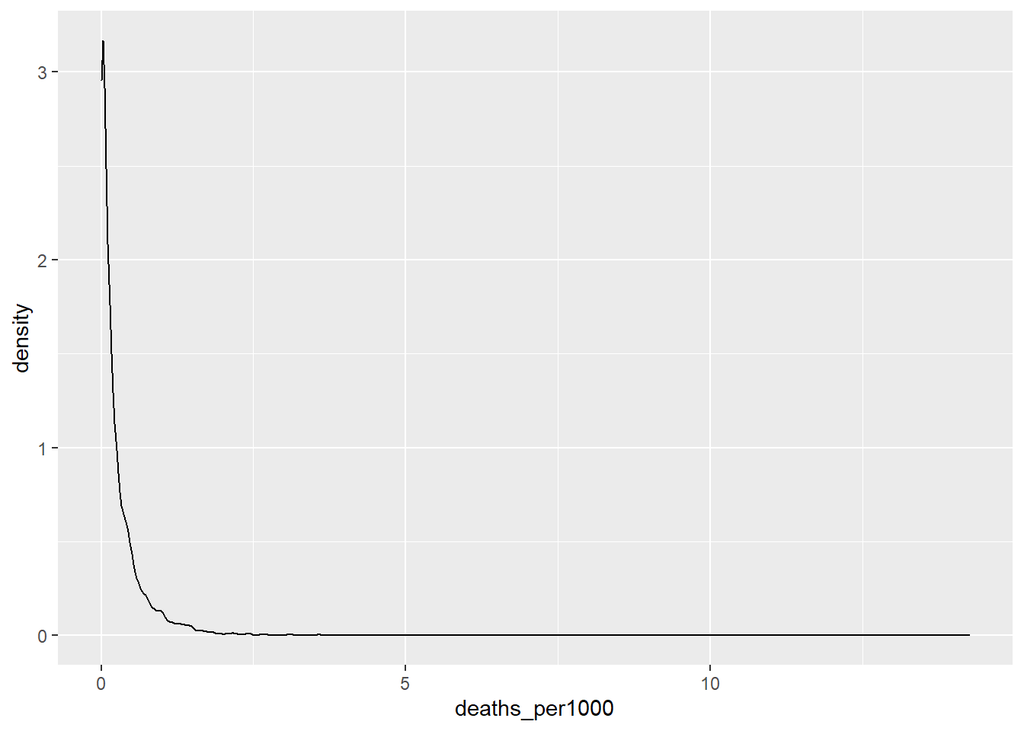

```r
ggplot(data_covid, aes(x = deaths_per1000)) + geom_density()
```

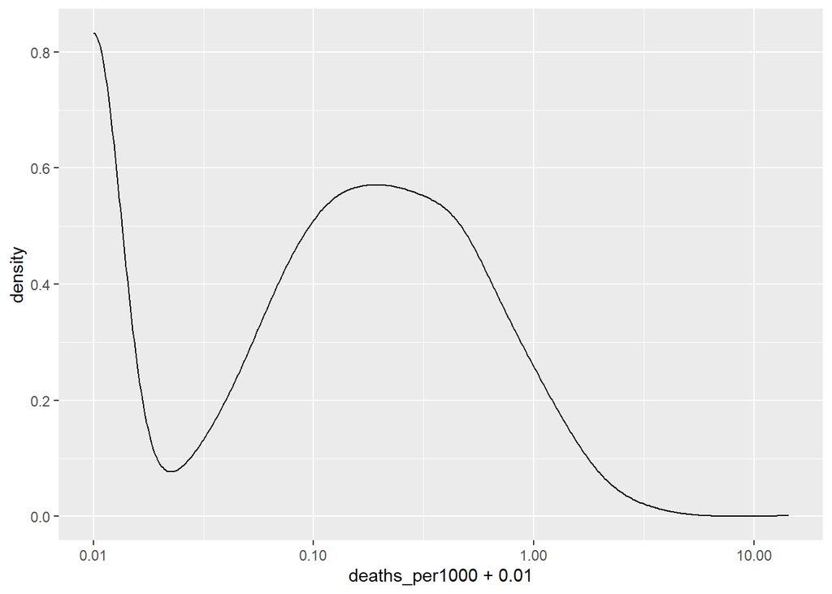

```r
ggplot(data_covid, aes(x = deaths_per1000 +.01)) + geom_density() + scale_x_log10()
```

## Decide the variable to include as input

- There are 47 variables what are possible predictors? Especially:
  - trump: pct_report, votes, total_votes, pct, lead,
  - demography: TotalPop, Men, Women, Hispanic, White, Black, Native, Asian, Pacific, VotingAgeCitizen, Income, IncomePerCap, Poverty, ChildPoverty, Professional, Service, Office, Construction, Production, Drive, Carpool, Transit, Walk, OtherTransp, WorkAtHome, MeanCommute, Employed, PrivateWork, PublicWork, SelfEmployed, FamilyWork, Unemployment
- What do you think should be included as the inputs?

```r
data_covid_use <- data_covid %>%
  mutate(deaths_per1000_log = log(deaths_per1000 + 0.01)) %>%
  select(deaths_per1000_log, Black, Hispanic, IncomePerCap,
         Poverty, Unemployment, pct)
```

## Data preparation

Here we need to prepare the data, in particular:

1. Train-test split
2. Data preprocessing

Using `caret` (or something else if you like), prepare two datasets of pre-processed train/test data.

## Train-test split

```r
set.seed(42)
train_id <- createDataPartition(data_covid_use$deaths_per1000_log, list = F, p = .7)
data_train <- data_covid_use %>% slice(train_id)
data_test <- data_covid_use %>% slice(-train_id)
```

## Preprocess

```r
prep <- data_train %>% select(-deaths_per1000_log) %>%
  preProcess(method = c("center", "scale"))

data_train_preped <- predict(prep, data_train)
data_test_preped <- predict(prep, data_test)
```

## Analysis

### Linear regression

- Run linear regression
- Evaluate the model

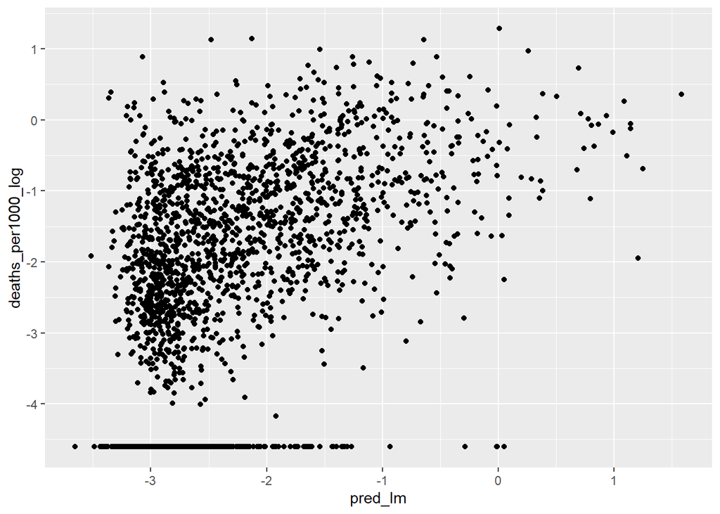

```r
model_lm <- lm(deaths_per1000_log ~ ., data = data_train_preped)
data_train_preped %>%
  mutate(pred_lm = predict(model_lm)) %>%
  ggplot(aes(x = pred_lm, y = deaths_per1000_log)) + geom_point()
```

```r
summary(model_lm)
```

```
##
## Call:
## lm(formula = deaths_per1000_log ~ ., data = data_train_preped)
##
## Residuals:
##     Min      1Q  Median      3Q     Max
## -4.6547 -1.4017  0.2116  1.0426  3.9550
##
## Coefficients:
##               Estimate Std. Error t value Pr(>|t|)
## (Intercept)  -2.334863   0.029595 -78.894  < 2e-16 ***
## Black         0.718464   0.038277  18.770  < 2e-16 ***
## Hispanic      0.349380   0.031712  11.017  < 2e-16 ***
## IncomePerCap  0.353026   0.050935   6.931 5.49e-12 ***
## Poverty       0.079883   0.054911   1.455    0.146
## Unemployment  0.171202   0.040542   4.223 2.51e-05 ***
## pct          -0.006963   0.039567  -0.176    0.860
## ---
## Signif. codes:  0 '***' 0.001 '**' 0.01 '*' 0.05 '.' 0.1 ' ' 1
##
## Residual standard error: 1.382 on 2173 degrees of freedom
## Multiple R-squared:  0.2648, Adjusted R-squared:  0.2627
## F-statistic: 130.4 on 6 and 2173 DF,  p-value: < 2.2e-16
```

```r
rmse_lm_trian <- (predict(model_lm) - data_train_preped$deaths_per1000_log)^2 %>% mean()
rmse_lm_test <- (predict(model_lm, newdata = data_test_preped) -
                   data_test_preped$deaths_per1000_log)^2 %>% mean()
```

### Additional movel evaluations

Using the linear regression model as the baseline we attempt two things:

1. Is it possible to improve the prediction using more flexible models?
- KNN-regression
- Or regression model variant of models covered in classificaiton section.
  - For example:
    - svm: svmPoly, svmRadial works both regression and classification (svmPoly may take quite long time as the number of tuning paramters are many.)
    - trees: rf

```r
ctrl <- trainControl(method = "repeatedcv",
                     number = 5,
                     repeats = 3)
model_knn <- train(deaths_per1000_log ~ ., data = data_train_preped,
   method = "knn", trControl = ctrl)

model_knn
```

```
## k-Nearest Neighbors
##
## 2180 samples
##    6 predictor
##
## No pre-processing
## Resampling: Cross-Validated (5 fold, repeated 3 times)
## Summary of sample sizes: 1744, 1744, 1744, 1744, 1744, 1744, ...
## Resampling results across tuning parameters:
##
##   k  RMSE      Rsquared   MAE
##   5  1.397814  0.2701870  1.106003
##   7  1.369415  0.2877736  1.092785
##   9  1.355656  0.2972135  1.086506
##
## RMSE was used to select the optimal model using the smallest value.
## The final value used for the model was k = 9.
```

```r
pred_train_knn <- predict(model_knn)
pred_test_knn <- predict(model_knn, newdata = data_test_preped)
rmse_train_knn <- (pred_train_knn - data_train_preped$deaths_per1000_log)^2 %>% mean()
rmse_test_knn <- (pred_test_knn -
                   data_test_preped$deaths_per1000_log)^2 %>% mean()

rmse_train_knn
```

```
## [1] 1.442798
```

```r
rmse_test_knn
```

```
## [1] 1.939391
```

### SVM with Radial Kernel

```r
ctrl <- trainControl(method = "repeatedcv",
                     number = 5,
                     repeats = 1)
model_svmradial <- train(deaths_per1000_log ~ ., data = data_train_preped,
   method = "svmRadial", trControl = ctrl)

model_svmradial
```

```
## Support Vector Machines with Radial Basis Function Kernel
##
## 2180 samples
##    6 predictor
##
## No pre-processing
## Resampling: Cross-Validated (5 fold, repeated 1 times)
## Summary of sample sizes: 1744, 1744, 1744, 1744, 1744
## Resampling results across tuning parameters:
##
##   C     RMSE      Rsquared   MAE
##   0.25  1.323353  0.3327544  1.037772
##   0.50  1.318105  0.3414404  1.028137
##   1.00  1.314649  0.3489489  1.019658
##
## Tuning parameter 'sigma' was held constant at a value of 0.2824843
## RMSE was used to select the optimal model using the smallest value.
## The final values used for the model were sigma = 0.2824843 and C = 1.
```

```r
pred_train_svmradial <- predict(model_svmradial)
pred_test_svmradial <- predict(model_svmradial, newdata = data_test_preped)
rmse_train_svmradial <- (pred_train_svmradial - data_train_preped$deaths_per1000_log)^2 %>% mean()
rmse_test_svmradial <- (pred_test_svmradial -
                   data_test_preped$deaths_per1000_log)^2 %>% mean()

rmse_train_svmradial
```

```
## [1] 1.464833
```

```r
rmse_test_svmradial
```

```
## [1] 1.859142
```

## LASSO and ridge regression

- Now, let’s run LASSO and/or Ridge regression.
- What do you find?
  - Shrinkage of the coefficients

### LASSO Outcome

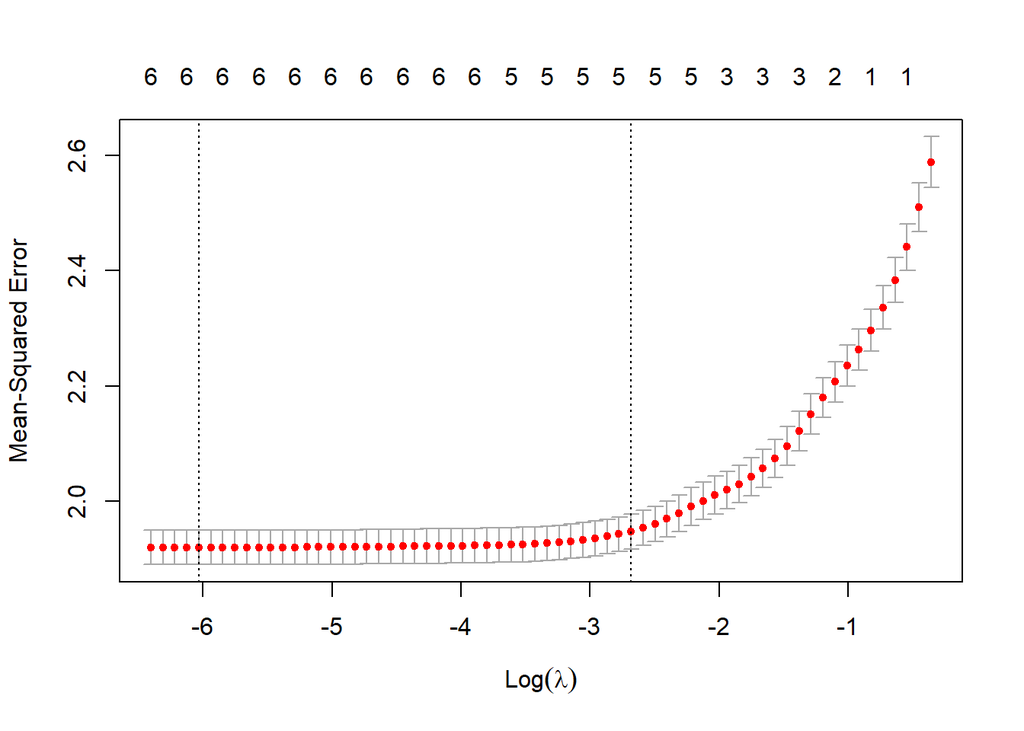

```r
data_train_x <- data_train_preped %>% select(!deaths_per1000_log) %>% as.matrix()
data_test_x <- data_test_preped %>% select(!deaths_per1000_log) %>% as.matrix()

model_lasso <- cv.glmnet(data_train_x, data_train_preped$deaths_per1000_log,
                             alpha = 1,
                                 type.measure = "mse",
                                 family = "gaussian")

plot(model_lasso)
```

```r
model_lasso
```

```
##
## Call:  cv.glmnet(x = data_train_x, y = data_train_preped$deaths_per1000_log,      type.measure = "mse", alpha = 1, family = "gaussian")
##
## Measure: Mean-Squared Error
##
##     Lambda Measure      SE Nonzero
## min 0.0024   1.920 0.02969       6
## 1se 0.0684   1.948 0.03026       5
```

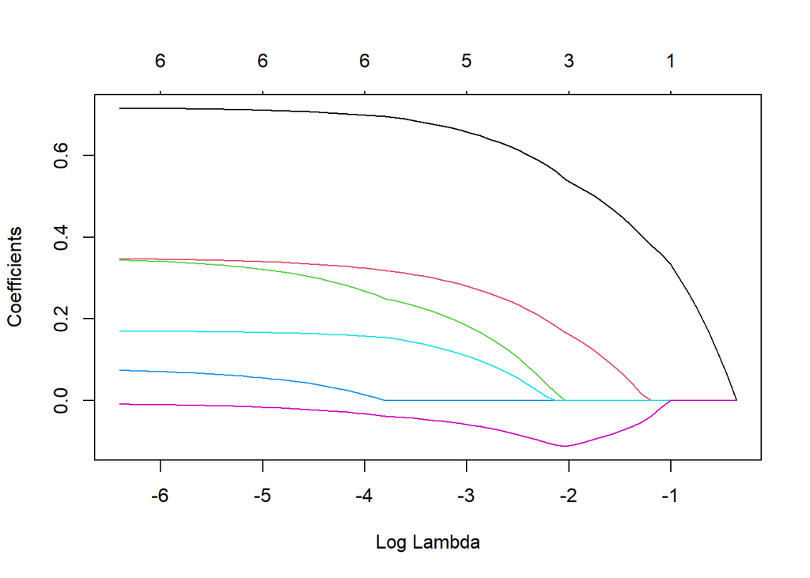

```r
pred_train_lasso <- predict(model_lasso, data_train_x)
pred_test_lasso <- predict(model_lasso, newx = data_test_x)
rmse_trian_lasso <- (pred_train_lasso - data_train_preped$deaths_per1000_log)^2 %>% mean()
rmse_test_lasso <- (pred_test_lasso -
                   data_test_preped$deaths_per1000_log)^2 %>% mean()
plot(model_lasso$glmnet.fit, xvar = "lambda")
```

```r
coef(model_lasso)
```

```
## 7 x 1 sparse Matrix of class "dgCMatrix"
##                        1
## (Intercept)  -2.33486253
## Black         0.63269467
## Hispanic      0.25377210
## IncomePerCap  0.13767954
## Poverty       .
## Unemployment  0.07721785
## pct          -0.07366315
```

### Ridge regression outcome

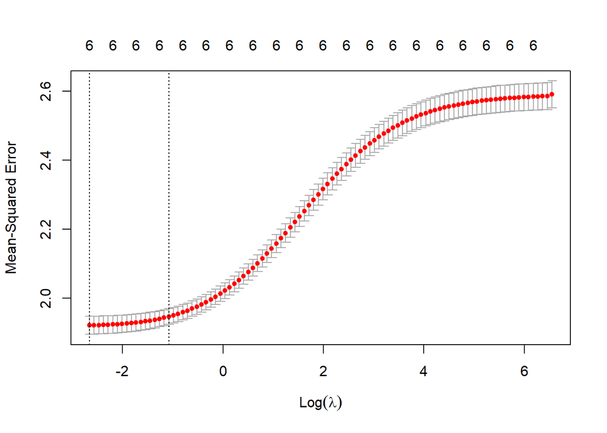

```r
model_ridge <- cv.glmnet(data_train_x, data_train_preped$deaths_per1000_log, data = data_train_preped,
                             alpha = 0,
                                 type.measure = "mse",
                                 family = "gaussian")

plot(model_ridge)
```

```r
model_ridge
```

```
##
## Call:  cv.glmnet(x = data_train_x, y = data_train_preped$deaths_per1000_log,      type.measure = "mse", data = data_train_preped, alpha = 0,      family = "gaussian")
##
## Measure: Mean-Squared Error
##
##     Lambda Measure      SE Nonzero
## min 0.0700   1.922 0.02620       6
## 1se 0.3404   1.947 0.02288       6
```

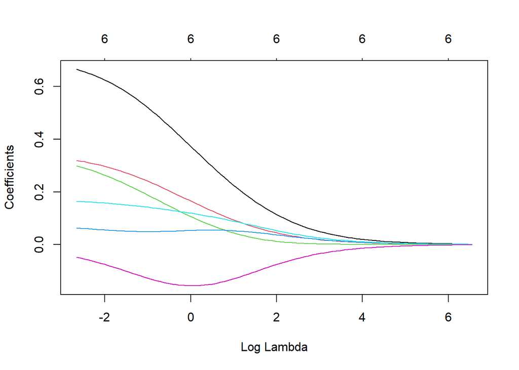

```r
pred_train_ridge <- predict(model_ridge, data_train_x)
pred_test_ridge <- predict(model_ridge, newx = data_test_x)
rmse_trian_ridge <- (pred_train_ridge - data_train_preped$deaths_per1000_log)^2 %>% mean()
rmse_test_ridge <- (pred_test_ridge -
                   data_test_preped$deaths_per1000_log)^2 %>% mean()
plot(model_ridge$glmnet.fit, xvar = "lambda")
```

```r
coef(model_ridge)
```

```
## 7 x 1 sparse Matrix of class "dgCMatrix"
##                        1
## (Intercept)  -2.33486253
## Black         0.53019764
## Hispanic      0.24601128
## IncomePerCap  0.19454603
## Poverty       0.04900038
## Unemployment  0.14345203
## pct          -0.12363564
```

### Compare coefs: lm, lasso/ridge

Compare the cefficients across the models. What do you find?

```r
list(model_lm, model_lasso, model_ridge) %>%
  map(~coef(.) %>% as.matrix %>% as.data.frame) %>% bind_cols() %>%
  rename(lm = 1, ridge = 2, lasso = 3)
```

[output not shown]

[figure not shown]

```r
list(model_lm, model_lasso, model_ridge) %>%
  map(~coef(.) %>% as.matrix %>% as.data.frame) %>% bind_cols() %>%
  rename(lm = 1, ridge = 2, lasso = 3) %>%
  rownames_to_column(var = "variable") %>% pivot_longer(2:4) %>%
  filter(variable != "(Intercept)") %>%
  ggplot(aes(x = value, y = variable, color = name)) + geom_point() +
  theme_minimal()
```